# Udemy-Linear Regression Project

## Training and Testing Data

Now that we've explored the data a bit, let's go ahead and split the data into training and testing sets. **Set a variable X equal to the numerical features of the customers and a variable y equal to the "Yearly Amount Spent" column.**

```python
features = df[['Avg. Session Length', 'Time on App','Time on Website', 'Length of Membership']]
```

```python
spent = df['Yearly Amount Spent']
```

```python
f_train, f_test, s_train, s_test = train_test_split(features, spent, test_size=0.35, random_state=10)
```

## Training the Model

time to train our model on our training data!

```python
# creat an opject form linerreression model
linear_model = LinearRegression()
```

```python
# Trianing our data
linear_model.fit(f_train, s_train)
```

```
LinearRegression()
```

```python
linear_model.intercept_
```

```
-1070.1215277188107
```

```python
# gitting the Coefficient of the model
linear_model.coef_
```

```
array([25.78931809, 38.65045753,  0.8695065 , 61.91990036])
```

```python
c_df = pd.DataFrame(data=linear_model.coef_, index=f_train.columns, columns=['Coefficient'])
c_df
```

|  | Coefficient |
| --- | --- |
| Avg. Session Length | 25.789318 |
| Time on App | 38.650458 |
| Time on Website | 0.869506 |
| Length of Membership | 61.919900 |

**Print out the coefficients of the model**

## Predicting Test Data

let's evaluate its performance by predicting off the test values

```python
s_pred = linear_model.predict(f_test)
```

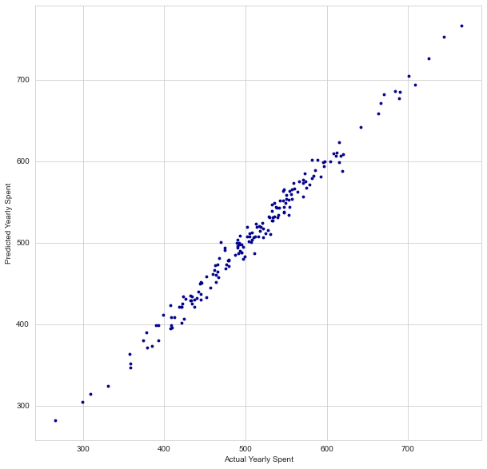

```python
# gitting the relation between our predicted data and our test data
plt.figure(figsize=(10,10))
plt.scatter(s_test,s_pred, color='darkblue', s=8,);
plt.xlabel('Actual Yearly Spent')
plt.ylabel('Predicted Yearly Spent')
```

## Evaluating the Model

*Calculateing the Mean Absolute Error, Mean Squared Error, and the Root Mean Squared Error.*

```python
mae = metrics.mean_absolute_error(s_test, s_pred)
mse = metrics.mean_squared_error(s_test, s_pred)
rmse = np.sqrt(mse)
# evaluation Dataframe
e_df = pd.DataFrame(data=[mae,mse,rmse], index=['MSE','MSE', 'RMSE'], columns=['Results'])
e_df
```

[output not shown]

## Residuals

**Plot a histogram of the residuals**

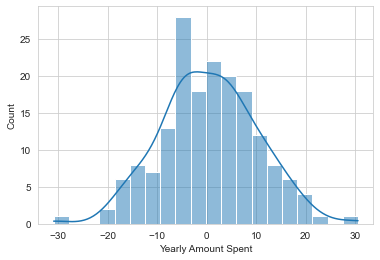

```python
sns.histplot(s_test-s_pred, kde=True, bins=20)
```

## Conclusion

We still want to answer to the original question, do we focus our efforst on mobile app or website development? Or maybe that doesn't even really matter, and Membership Time is what is really important. Let's see if we can interpret the coefficients at all to get an idea.

```python
c_df
```

|  | Coefficient |
| --- | --- |
| Avg. Session Length | 25.789318 |
| Time on App | 38.650458 |
| Time on Website | 0.869506 |
| Length of Membership | 61.919900 |

**Do you think the company should focus more on their mobile app or on their website?**

### However, it is tricky, should we develop the website to be as good as a mobile app? or spend more on the app as it already doing better?!, That's depends on other factors such as the relation between Length of membership and Time on app